# heidi

[figure not shown]

**Institution Profile**

**Classification:** Professions-focused Undergraduate/Graduate-Doctorate Small

**Size:** Small

**Award Level Focus:** Undergraduate/Graduate-Doctorate

**UG Program Mix:** Professions-focused

**Grad Program Mix:** Special Focus: Other Health Professions

**Research Activity:** No research designation

**Student Access & Earnings:** Higher Access, Medium Earnings

**Top Degree Programs — 2023-24**

| Program | % of Degrees |
| --- | --- |
| Registered Nursing, Nursing Administration, Nursing Research and Clinical Nursing. | 11.8% |
| Business Administration, Management and Operations. | 11.5% |
| Rehabilitation and Therapeutic Professions. | 10.6% |

**Location**

[interactive chart not shown]

#### Higher Education Institutional Data Interface (HEIDI)

HEIDI is a dashboard tool created by the Casagrande Institute to report data for institutions of higher education.

#### Casagrande Institute

The [Casagrande Institute](https://www.viterbo.edu/casagrande-institute/) helps institutions develop effective compensation practices for executives, faculty, and staff.

**Group Overview**

- **AUTO**: Created by IPEDS in 2024-25 based on an internal grouping process involving Level, Control, Carnegie classification, and other variables.
- **CUSTOM**: The group of comparison institutions submitted to IPEDS by Lenoir-Rhyne in 2024-25.
- **REVERSE**: The group of institutions that included Lenoir-Rhyne in their 2024-25 IPEDS custom group.

**Group Membership**

| Institution | AUTO | CUSTOM | REVERSE |
| --- | --- | --- | --- |
| Alfred University | ✓ |  |  |
| Anderson University |  | ✓ |  |
| Barton College |  | ✓ |  |
| Belmont Abbey College |  | ✓ | ✓ |
| Berry College |  | ✓ |  |
| Bethany College |  |  | ✓ |
| Brevard College |  |  | ✓ |
| Bridgewater College |  |  | ✓ |
| Canisius University | ✓ |  |  |
| Capital University | ✓ |  |  |

[output cut: 60 more lines]

**AUTO**

[interactive table not shown]

**CUSTOM**

[interactive table not shown]

**REVERSE**

[interactive table not shown]

**AUTO**

**Financial and Student Positioning of Lenoir-Rhyne Within the AUTO Group**

| Metric | **AUTO Group** n | **AUTO Group** Min | **AUTO Group** p25 | **AUTO Group** Median | **AUTO Group** p75 | **AUTO Group** Max | **Spread** Spread | **Lenoir-Rhyne** Lenoir-Rhyne | **Lenoir-Rhyne** Percentile | **Lenoir-Rhyne** % of Median |
| --- | --- | --- | --- | --- | --- | --- | --- | --- | --- | --- |
| Revenue | 29 | 27.7M | 56.2M | 73.7M | 92.7M | 210.9M |  | 64.8M | 40 | 88% |
| Expenses | 29 | 17.1M | 55.0M | 68.9M | 83.0M | 189.0M |  | 62.8M | 36 | 91% |
| Margin | 29 | −7.2M | 311.9k | 5.1M | 10.6M | 24.8M |  | 2.1M | 36 | 40% |
| Endowment | 28 | 5.1M | 49.2M | 87.3M | 147.3M | 427.8M |  | 136.1M | 70 | 156% |
| Avg Net Price | 30 | 15.3k | 20.6k | 23.7k | 28.5k | 43.5k |  | 21.5k | 35 | 91% |
| Avg Net Price + 0.04 * Endowment / UG FTE | 28 | 15.9k | 23.0k | 27.0k | 31.6k | 51.5k |  | 25.4k | 41 | 94% |
| 12-Month Unduplicated Headcount | 30 | 2,300 | 2,826 | 3,088 | 3,544 | 6,222 |  | 2,488 | 5 | 81% |
| Undergrad FTE | 30 | 438 | 1,253 | 1,665 | 1,796 | 2,191 |  | 1,403 | 38 | 84% |
| Grad FTE | 30 | 113 | 444 | 554 | 762 | 1,977 |  | 646 | 65 | 117% |
| Doc Prof Prac FTE | 9 | 3 | 88 | 117 | 403 | 1,804 |  | NA | 0 | NA |
| Total FTE | 30 | 1,764 | 2,087 | 2,388 | 2,482 | 2,608 |  | 2,049 | 22 | 86% |
| Student-to-Faculty Ratio | 30 | 8.0 | 10.0 | 12.0 | 13.0 | 25.0 |  | 15.0 | 88 | 125% |
| Undergrad Pell % | 30 | 11 | 26 | 34 | 44 | 58 |  | 39 | 67 | 113% |
| Program Breadth (distinct 4-digit CIPs) | 30 | 13 | 31 | 38 | 43 | 49 |  | 44 | 82 | 114% |
| Top 5 Programs % of Completions | 30 | 40 | 50 | 58 | 75 | 86 |  | 49 | 25 | 84% |
| Distinct Award Levels Offered | 30 | 2 | 3 | 4 | 6 | 9 |  | 3 | 18 | 75% |

Data from IPEDS for the 2024-25 academic year. Group values exclude data from Lenoir-Rhyne.

**CUSTOM**

**Financial and Student Positioning of Lenoir-Rhyne Within the CUSTOM Group**

| Metric | **CUSTOM Group** n | **CUSTOM Group** Min | **CUSTOM Group** p25 | **CUSTOM Group** Median | **CUSTOM Group** p75 | **CUSTOM Group** Max | **Spread** Spread | **Lenoir-Rhyne** Lenoir-Rhyne | **Lenoir-Rhyne** Percentile | **Lenoir-Rhyne** % of Median |
| --- | --- | --- | --- | --- | --- | --- | --- | --- | --- | --- |
| Revenue | 20 | 25.7M | 44.2M | 64.1M | 81.8M | 249.3M |  | 64.8M | 52 | 101% |
| Expenses | 20 | 28.3M | 41.7M | 56.8M | 74.6M | 113.0M |  | 62.8M | 57 | 111% |
| Margin | 20 | −8.8M | −2.3M | 3.6M | 9.2M | 136.3M |  | 2.1M | 38 | 57% |
| Endowment | 20 | 13.8M | 32.2M | 70.3M | 117.1M | 1.4B |  | 136.1M | 82 | 194% |
| Avg Net Price | 20 | 18.4k | 20.4k | 21.2k | 24.1k | 31.8k |  | 21.5k | 68 | 102% |
| Avg Net Price + 0.04 * Endowment / UG FTE | 20 | 20.9k | 21.8k | 24.2k | 25.7k | 50.3k |  | 25.4k | 72 | 105% |
| 12-Month Unduplicated Headcount | 20 | 1,114 | 1,365 | 1,891 | 3,512 | 4,964 |  | 2,488 | 68 | 132% |
| Undergrad FTE | 20 | 859 | 1,052 | 1,456 | 2,215 | 3,113 |  | 1,403 | 42 | 96% |
| Grad FTE | 20 | 5 | 71 | 141 | 537 | 1,058 |  | 646 | 88 | 458% |
| Doc Prof Prac FTE | 8 | 27 | 121 | 154 | 193 | 285 |  | NA | 0 | NA |
| Total FTE | 20 | 975 | 1,147 | 1,673 | 2,710 | 3,848 |  | 2,049 | 62 | 122% |
| Student-to-Faculty Ratio | 20 | 9.0 | 12.0 | 12.0 | 13.0 | 18.0 |  | 15.0 | 90 | 125% |
| Undergrad Pell % | 20 | 21 | 27 | 34 | 39 | 49 |  | 39 | 78 | 116% |
| Program Breadth (distinct 4-digit CIPs) | 20 | 20 | 26 | 32 | 41 | 57 |  | 44 | 88 | 140% |
| Top 5 Programs % of Completions | 20 | 31 | 47 | 56 | 62 | 77 |  | 49 | 32 | 87% |
| Distinct Award Levels Offered | 20 | 1 | 2 | 3 | 4 | 8 |  | 3 | 57 | 100% |

Data from IPEDS for the 2024-25 academic year. Group values exclude data from Lenoir-Rhyne.

**REVERSE**

**Financial and Student Positioning of Lenoir-Rhyne Within the REVERSE Group**

| Metric | **REVERSE Group** n | **REVERSE Group** Min | **REVERSE Group** p25 | **REVERSE Group** Median | **REVERSE Group** p75 | **REVERSE Group** Max | **Spread** Spread | **Lenoir-Rhyne** Lenoir-Rhyne | **Lenoir-Rhyne** Percentile | **Lenoir-Rhyne** % of Median |
| --- | --- | --- | --- | --- | --- | --- | --- | --- | --- | --- |
| Revenue | 22 | 2.6M | 26.3M | 41.5M | 59.8M | 127.2M |  | 64.8M | 80 | 156% |
| Expenses | 22 | 2.9M | 26.2M | 39.4M | 55.2M | 104.1M |  | 62.8M | 89 | 159% |
| Margin | 22 | −8.8M | −3.5M | 883.2k | 3.5M | 70.3M |  | 2.1M | 66 | 233% |
| Endowment | 21 | 10.3M | 37.0M | 49.8M | 75.5M | 197.8M |  | 136.1M | 93 | 273% |
| Avg Net Price | 21 | 11.3k | 22.3k | 23.9k | 26.8k | 45.5k |  | 21.5k | 26 | 90% |
| Avg Net Price + 0.04 * Endowment / UG FTE | 21 | 14.3k | 23.4k | 26.1k | 28.9k | 46.0k |  | 25.4k | 40 | 97% |
| 12-Month Unduplicated Headcount | 24 | 213 | 1,067 | 1,436 | 2,144 | 4,157 |  | 2,488 | 85 | 173% |
| Undergrad FTE | 24 | 159 | 802 | 1,040 | 1,409 | 3,003 |  | 1,403 | 73 | 135% |
| Grad FTE | 21 | 8 | 75 | 144 | 320 | 1,058 |  | 646 | 93 | 449% |
| Doc Prof Prac FTE | 4 | 56 | 72 | 129 | 190 | 222 |  | NA | 0 | NA |
| Total FTE | 24 | 159 | 861 | 1,243 | 1,696 | 3,729 |  | 2,049 | 85 | 165% |
| Student-to-Faculty Ratio | 24 | 8.0 | 11.0 | 12.0 | 14.0 | 21.0 |  | 15.0 | 88 | 125% |
| Undergrad Pell % | 24 | 23 | 32 | 40 | 44 | 73 |  | 39 | 46 | 98% |
| Program Breadth (distinct 4-digit CIPs) | 24 | 5 | 22 | 28 | 36 | 43 |  | 44 | 100 | 157% |
| Top 5 Programs % of Completions | 24 | 39 | 48 | 58 | 62 | 100 |  | 49 | 29 | 85% |
| Distinct Award Levels Offered | 24 | 1 | 2 | 3 | 5 | 7 |  | 3 | 50 | 100% |

Data from IPEDS for the 2024-25 academic year. Group values exclude data from Lenoir-Rhyne.

**AUTO**

**Revenue**

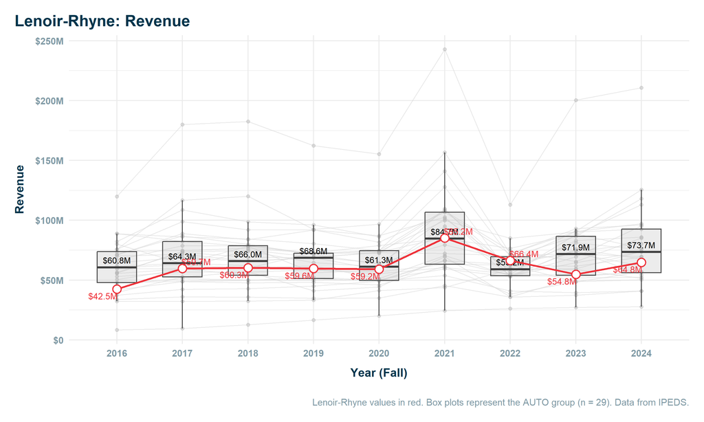

**Expenses**

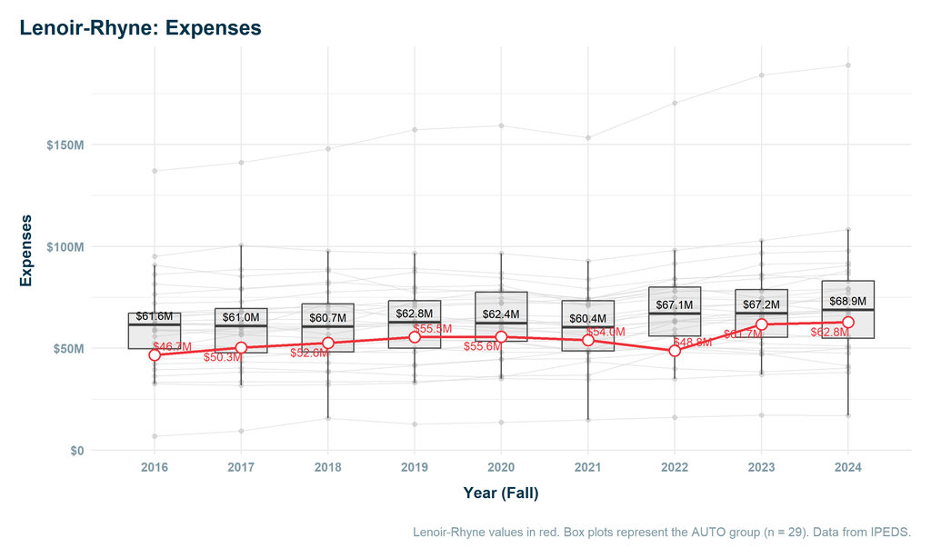

**Margin**

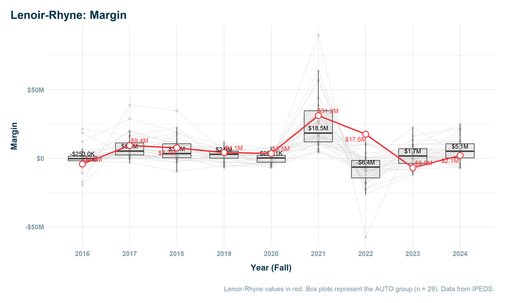

**Endowment**

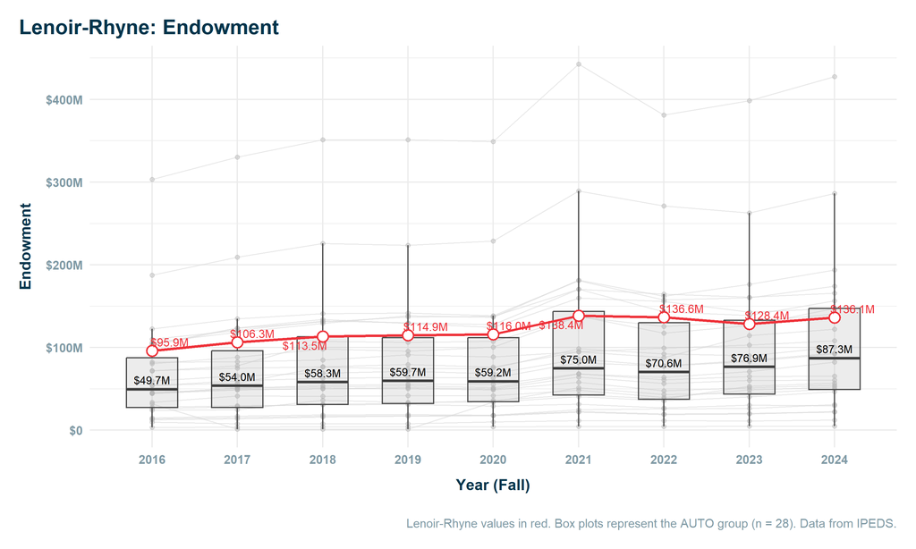

**Avg Net Price**

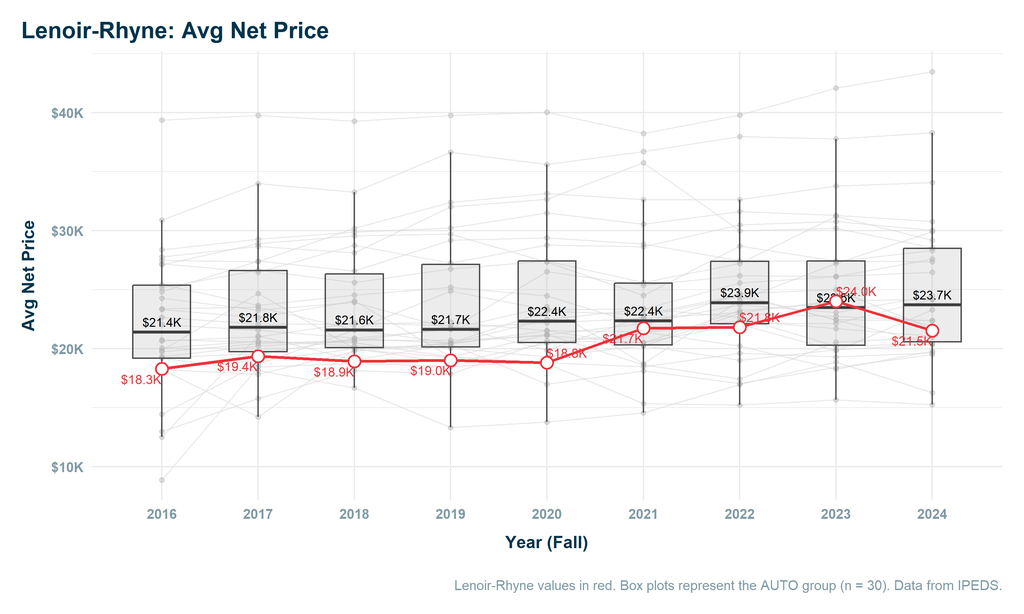

**Avg Net Price + 0.04 * Endowment / UG FTE**

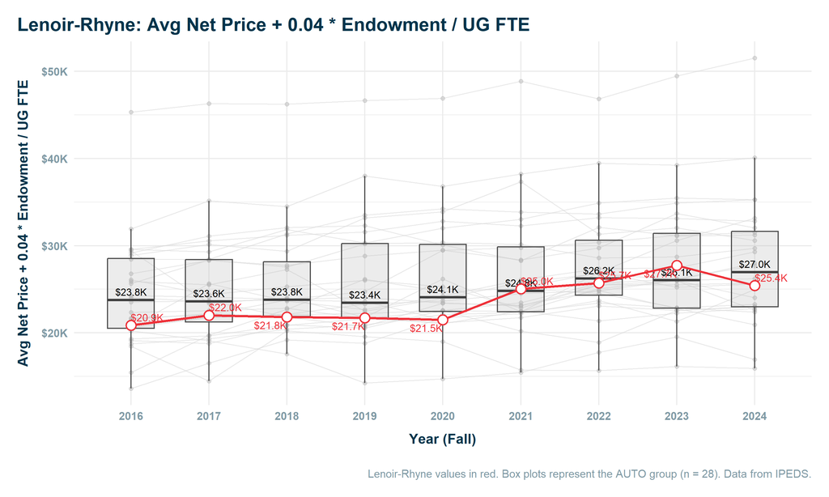

**12-Month Unduplicated Headcount**

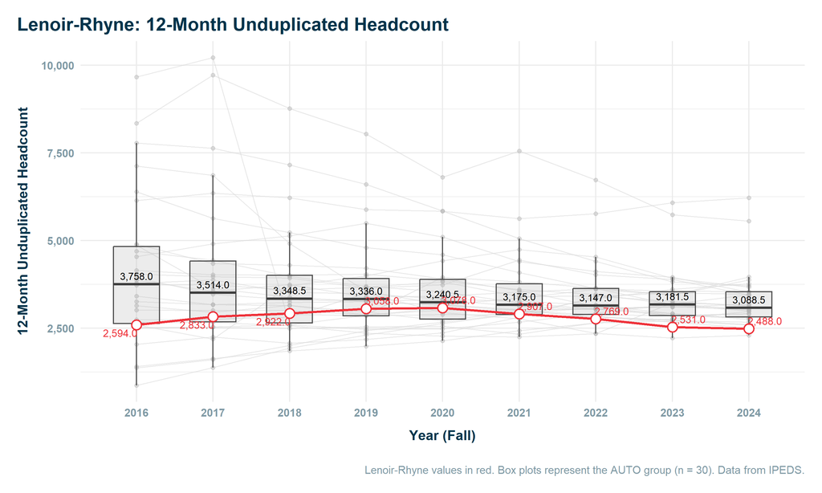

**Undergrad FTE**

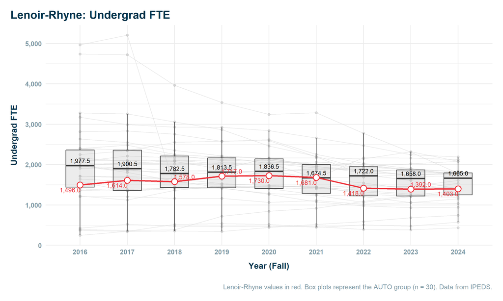

**Grad FTE**

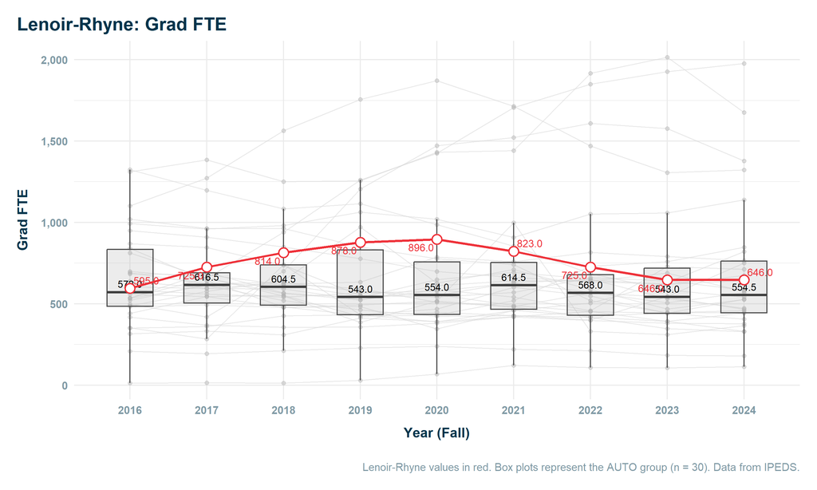

**Doc Prof Prac FTE**

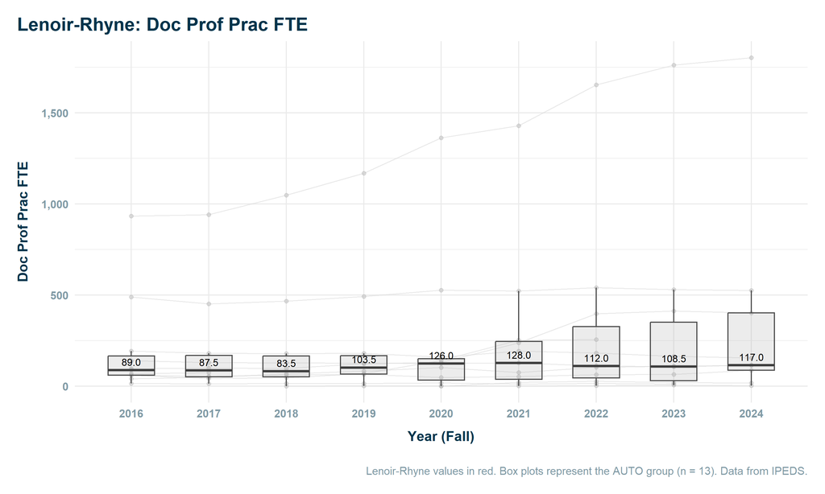

**Total FTE**

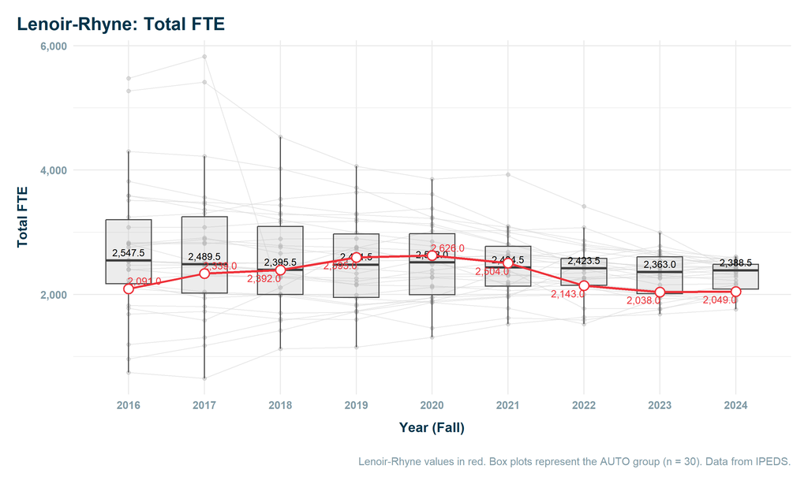

**Student-to-Faculty Ratio**

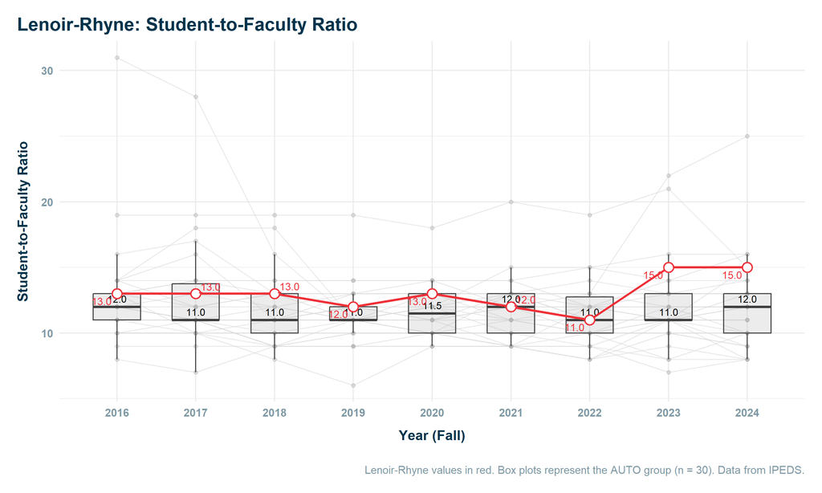

**Undergrad Pell %**

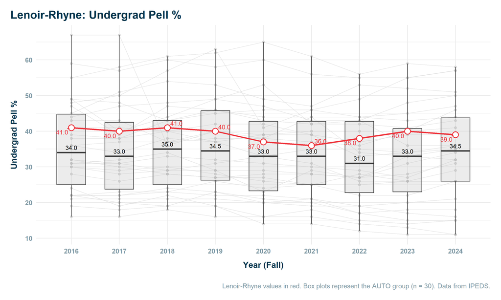

**Program Breadth (distinct 4-digit CIPs)**

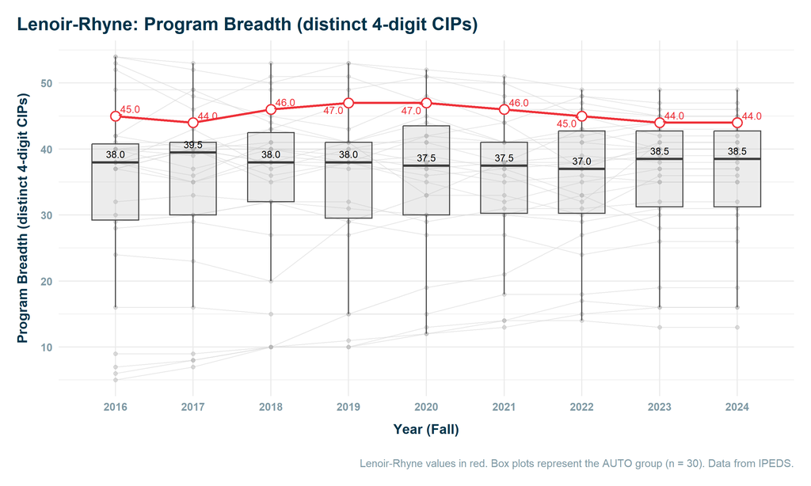

**Top 5 Programs % of Completions**

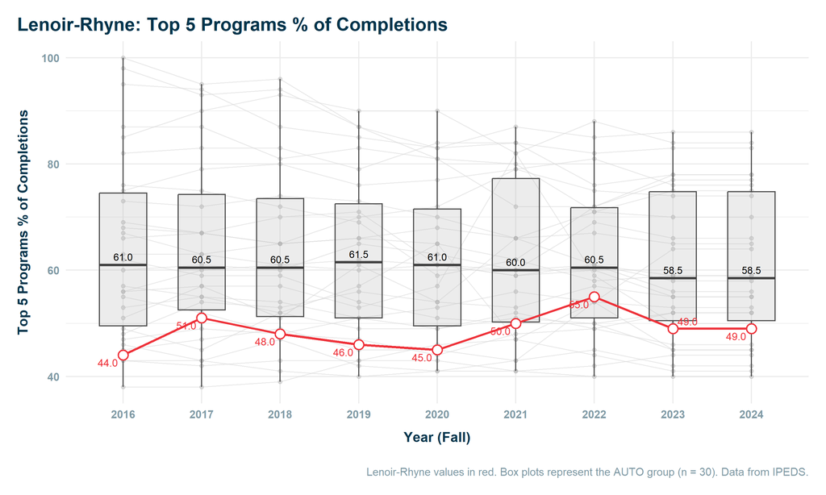

**Distinct Award Levels Offered**

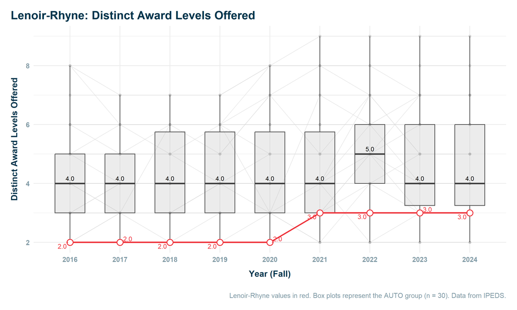

**CUSTOM**

**Revenue**

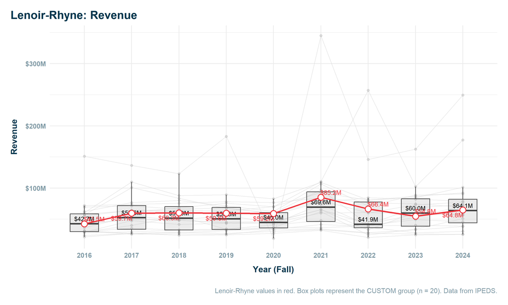

**Expenses**

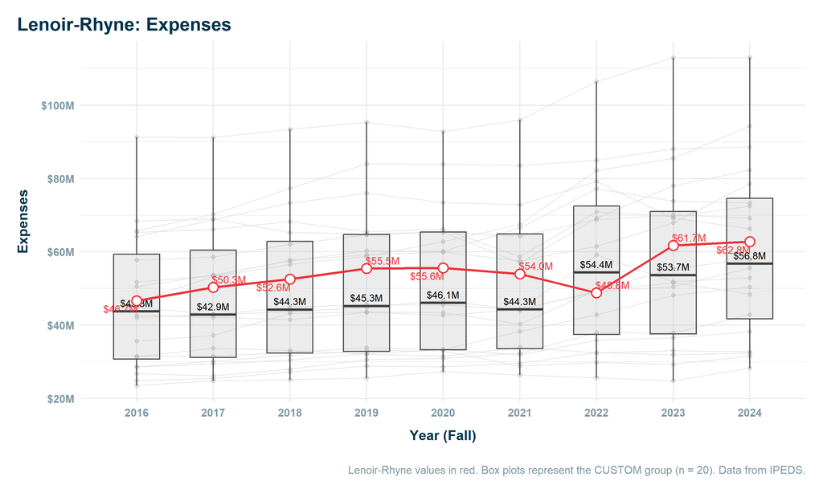

**Margin**

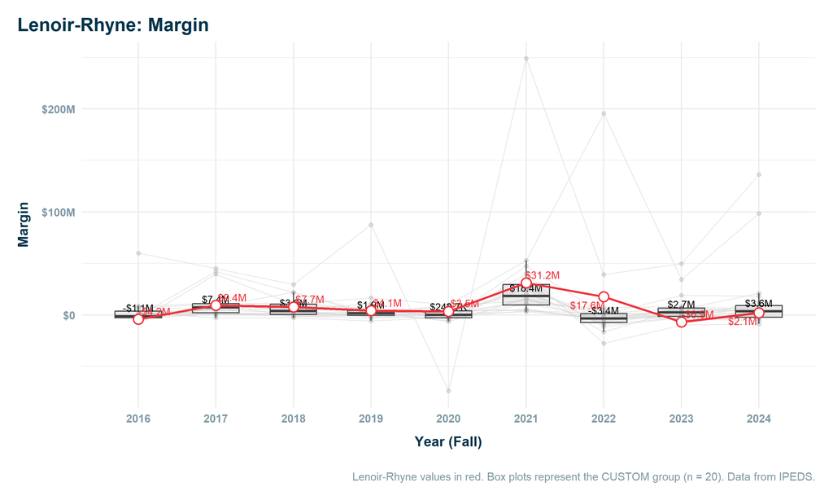

**Endowment**

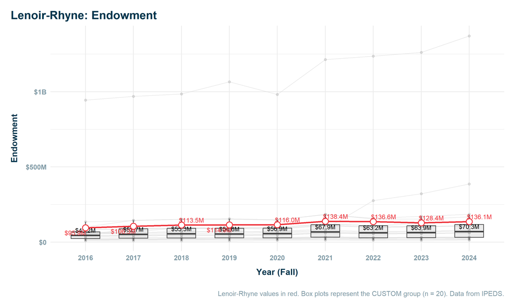

**Avg Net Price**

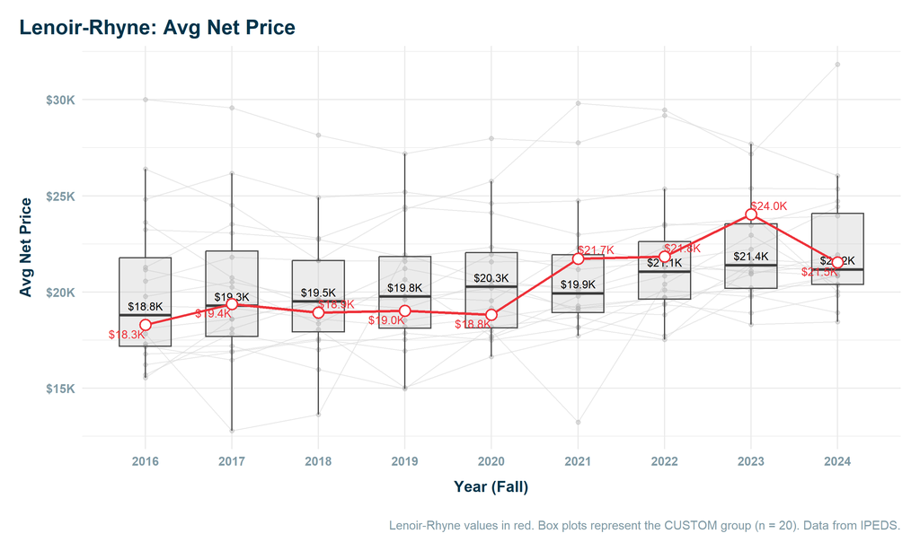

**Avg Net Price + 0.04 * Endowment / UG FTE**

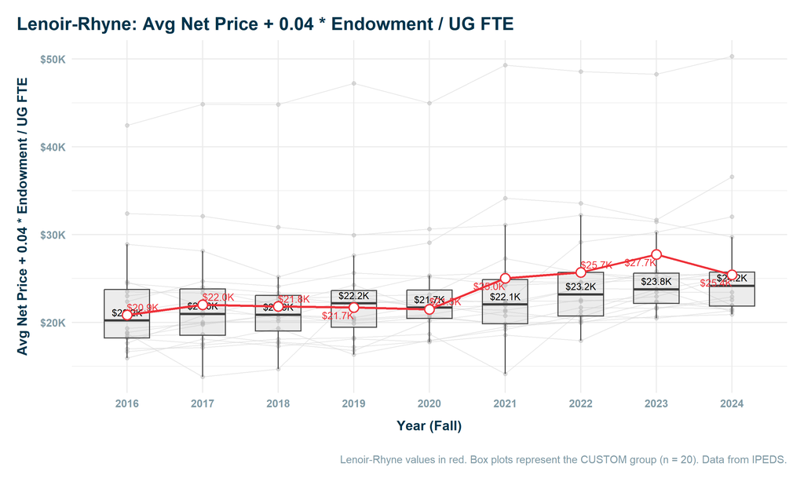

**12-Month Unduplicated Headcount**

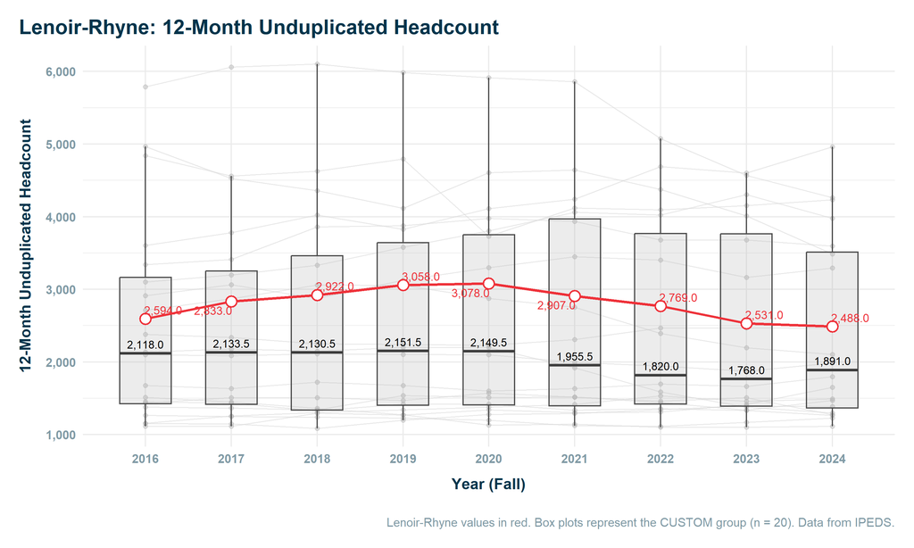

**Undergrad FTE**

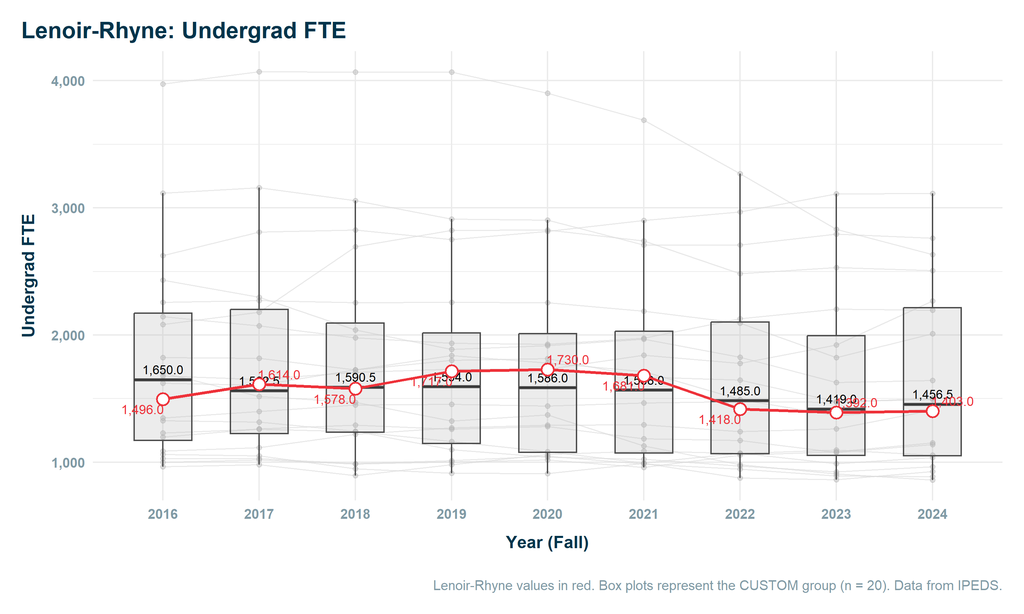

**Grad FTE**

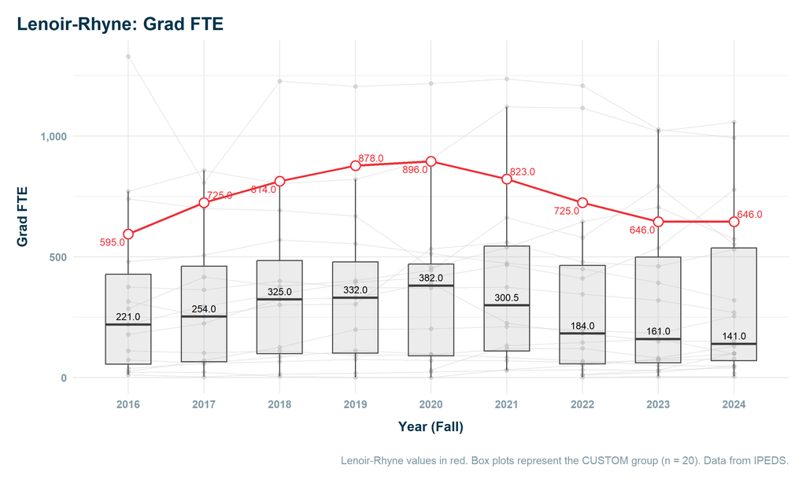

**Doc Prof Prac FTE**

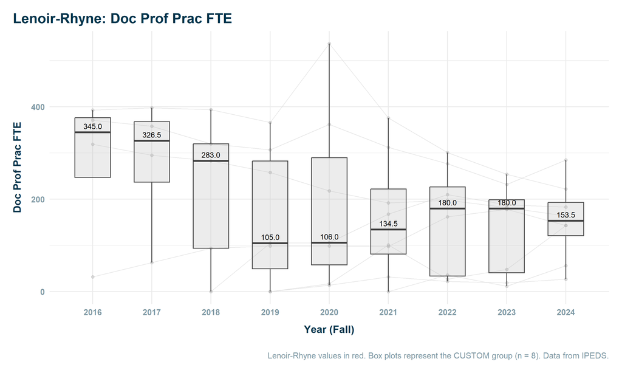

**Total FTE**

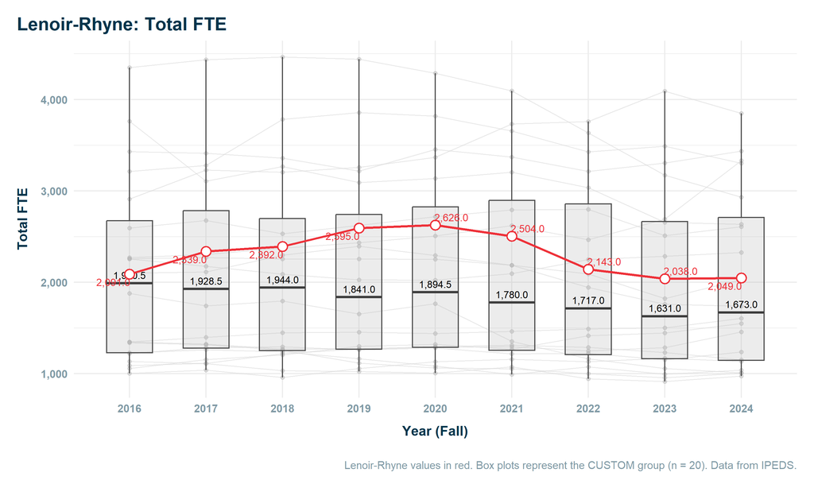

**Student-to-Faculty Ratio**

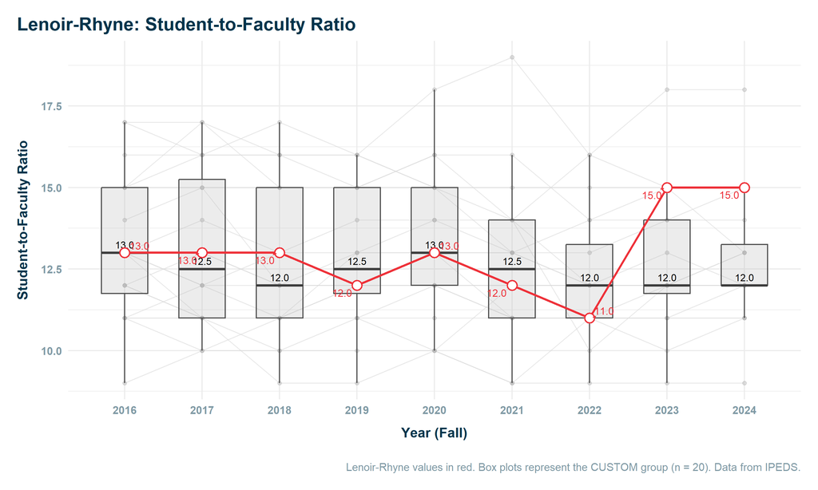